# CSC421 Fall 2023 Assignment 4

# Question 5 (Expected) - Show misclassification examples

Write a function that takes as input a particular class (for example dog) and shows an array of images (similar to the functions showing images in the deep learning notebook) in which each row contains 10 example images from another class that were misclassified. The resulting grid will have 9 rows (one for each class other than the input class) and 10 examples. For example the row for truck would have images of trucks that were misclassified as dogs. Show the output of this function for the SVM classifier and the class horse.

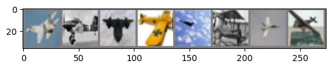

```
plane plane plane plane plane plane plane plane
```

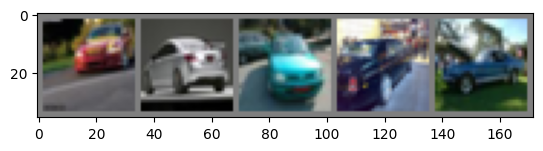

```
  car   car   car   car   car
```

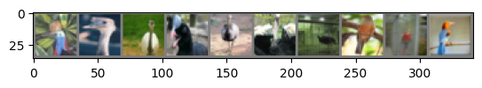

```
 bird  bird  bird  bird  bird  bird  bird  bird  bird  bird
```

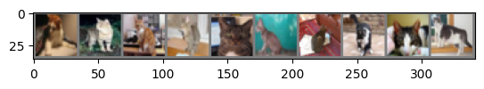

```
  cat   cat   cat   cat   cat   cat   cat   cat   cat   cat
```

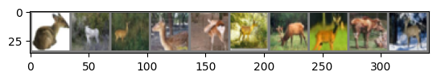

```
 deer  deer  deer  deer  deer  deer  deer  deer  deer  deer
```

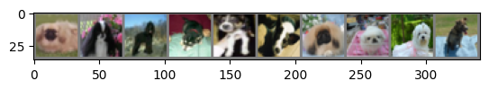

```
  dog   dog   dog   dog   dog   dog   dog   dog   dog   dog
```

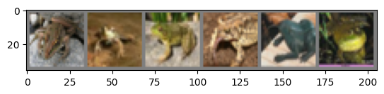

```
 frog  frog  frog  frog  frog  frog
```

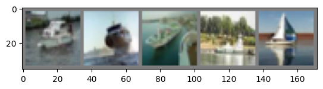

```
 ship  ship  ship  ship  ship
```

[figure not shown]

```
truck truck truck truck truck truck truck truck truck truck
```

```python
import matplotlib.pyplot as plt
import numpy as np

className = ['airplanes', 'cars', 'birds', 'cats', 'deer', 'dogs', 'frogs', 'horses', 'ships', 'trucks']
my_list = [[] * 9 for _ in range(10)]
classList = [[] * 9 for _ in range(10)]

def imshow(img):
    img = img / 2 + 0.5     # unnormalize
    npimg = img.numpy()
    plt.imshow(np.transpose(npimg, (1, 2, 0)))
    plt.show()

def missClass(classNum):
    dataiter = iter(testloader)
    images, labels = next(dataiter)
    for i in range(len(ytest)):
        if (i%32 == 0 and i > 0):
            images, labels = next(dataiter)

        if (ytest[i] != ytest_predict[i] and ytest_predict[i] == classNum):
            if ( len(my_list[ytest[i]]) < 10):
                my_list[ytest[i]].append(images[i%32])
                classList[ytest[i]].append(labels[i%32])

    for j in range(len(my_list)):
        if (len(my_list[j]) > 0):
            imshow(torchvision.utils.make_grid(my_list[j], nrow=10))
            print(' '.join('%5s' % classes[a] for a in classList[j]))
missClass(7)
```

# Question 6 (Expected) - Comparison of different features

In the deep learning notebook the CIFAR-10 classification code using SVM utilizes a histogram of oriented gradients features followed by a PCA transformation for dimensionality reduction. Using the mini-CIFAR-10 dataset compare the following three feature front-ends using SVM classificaiton (use the same parameters as the deep learning notebook):

1. Flatten the training images to a single (32 * 32 * 3) vector
2. Compute the Histogram of Gradients
3. Computer the Histogram of Gradients followed by PCA (as done in the deep learning notebook).

Compare these three feature front ends by showing the corresponding classification accurarcy and confusion matrices for each one.

```
Files already downloaded and verified
Files already downloaded and verified
5000
5000
0
0
1000
2000
3000
4000
start printing
flatten training
              precision    recall  f1-score   support

           0       0.46      0.52      0.49       488
           1       0.57      0.54      0.56       505
           2       0.34      0.37      0.36       512
           3       0.30      0.29      0.30       497
           4       0.40      0.41      0.41       507
           5       0.35      0.31      0.33       488
           6       0.49      0.49      0.49       491
           7       0.54      0.46      0.50       495
           8       0.56      0.65      0.60       504
           9       0.52      0.50      0.51       513

    accuracy                           0.45      5000
   macro avg       0.45      0.45      0.45      5000
weighted avg       0.45      0.45      0.45      5000
```

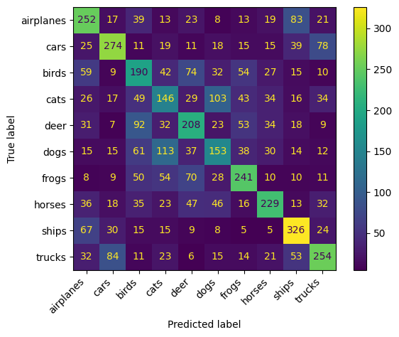

```
hog
              precision    recall  f1-score   support

           0       0.57      0.65      0.60       488
           1       0.70      0.72      0.71       505
           2       0.45      0.49      0.47       512
           3       0.40      0.38      0.39       497
           4       0.49      0.50      0.50       507
           5       0.44      0.39      0.41       488
           6       0.61      0.64      0.62       491
           7       0.65      0.58      0.62       495
           8       0.64      0.64      0.64       504
           9       0.68      0.64      0.66       513

    accuracy                           0.56      5000
   macro avg       0.56      0.56      0.56      5000
weighted avg       0.56      0.56      0.56      5000
```

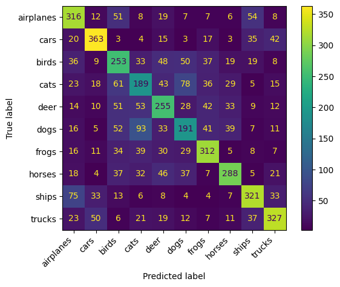

```
hog + pca
              precision    recall  f1-score   support

           0       0.55      0.62      0.58       488
           1       0.69      0.70      0.69       505
           2       0.47      0.47      0.47       512
           3       0.36      0.35      0.36       497
           4       0.48      0.48      0.48       507
           5       0.41      0.38      0.39       488
           6       0.58      0.63      0.61       491
           7       0.62      0.56      0.59       495
           8       0.61      0.64      0.62       504
           9       0.67      0.64      0.65       513

    accuracy                           0.55      5000
   macro avg       0.55      0.55      0.55      5000
weighted avg       0.55      0.55      0.55      5000
```

```python
# Your code goes here
import torch
import torchvision
import torchvision.transforms as transforms
transform = transforms.Compose(
    [transforms.ToTensor(),
     transforms.Normalize((0.5, 0.5, 0.5), (0.5, 0.5, 0.5))])
batch_size = 32

import matplotlib.pyplot as plt
import numpy as np

# Import datasets, classifiers and performance metrics
from sklearn import datasets, metrics, svm
from sklearn.naive_bayes import GaussianNB
from sklearn.metrics import classification_report


trainset = torchvision.datasets.CIFAR10(root='./data', train=True,
                                        download=True, transform=transform)
testset = torchvision.datasets.CIFAR10(root='./data', train=False,
                                       download=True, transform=transform)

trainset.data = trainset.data[:5000]
trainset.targets = trainset.targets[:5000]
testset.data = testset.data[:5000]
testset.targets = testset.targets[:5000]

trainloader = torch.utils.data.DataLoader(trainset, batch_size=batch_size,
                                          shuffle=True, num_workers=4)
testloader = torch.utils.data.DataLoader(testset, batch_size=batch_size,
                                         shuffle=False, num_workers=4)

classes = ('plane', 'car', 'bird', 'cat',
           'deer', 'dog', 'frog', 'horse', 'ship', 'truck')


# print(Xtrain)
train_n_samples = len(trainset.data)
print(train_n_samples)
test_n_samples = len(testset.data)
print(test_n_samples)

Xtrain = trainset.data
Xtest  = testset.data


# number 1
nsample, x, y, z = Xtrain.shape
Xtrain1 = Xtrain.reshape(nsample,32 * 32 * 3)
# Xtrain1 = Xtrain.flatten('F').reshape(nsample,32 * 32 * 3)
# print(Xtrain1)

nsample, x, y, z = Xtest.shape
Xtest1 = Xtest.reshape(nsample,32 * 32 * 3)

# number 2
from skimage.feature import hog

Xtrain_hog = []
for i in range(len(Xtrain)):
    fd  = hog(Xtrain[i] , orientations=9 , pixels_per_cell = (8,8),
                     cells_per_block = (2,2) , visualize = False, channel_axis=-1)
    Xtrain_hog.append(fd)
    if ((i % 10000) == 0):
        print(i)

Xtrain2 = np.array(Xtrain_hog)
# print(Xtrain2)
# print('Done calculating HOGs for training')
# print(Xtrain_hog.shape)

Xtest_hog = []
for i in range(len(Xtest)):
    fd = hog(Xtest[i] , orientations=9 , pixels_per_cell = (8,8),
                     cells_per_block = (2,2) , visualize = False, channel_axis=-1)
    Xtest_hog.append(fd)
    if ((i % 1000) == 0):
        print(i)

Xtest2 = np.array(Xtest_hog)
# print(Xtrain2)

ytrain = trainset.targets
ytest  = testset.targets

# number 3
from sklearn.decomposition import PCA
pca = PCA(0.8)
Xtrain3 = pca.fit_transform(Xtrain2)
Xtest3  = pca.transform(Xtest2)


# # %%time

from sklearn.metrics import confusion_matrix, ConfusionMatrixDisplay
# Create a classifier: a support vector classifier
def printAccAndMat(xtr, xte):
    clf = svm.SVC(C=10, cache_size=10000)
    clf.fit(xtr, ytrain)

    ytest_predict  = clf.predict(xte)
    print(classification_report(ytest, ytest_predict))

    color = 'white'
    cmSVM = confusion_matrix(ytest, ytest_predict)
    disp = ConfusionMatrixDisplay(cmSVM, display_labels=['airplanes', 'cars', 'birds', 'cats', 'deer', 'dogs', 'frogs', 'horses', 'ships', 'trucks'])
    disp.plot()
    plt.xticks(rotation=45, ha='right')
    plt.show()
    print('')

print("start printing")
print("flatten training")
printAccAndMat(Xtrain1, Xtest1)
print("hog")
printAccAndMat(Xtrain2, Xtest2)
print("hog + pca")
printAccAndMat(Xtrain3, Xtest3)
```

[output not shown]

# QUESTION 7 (Basic) - Deep learning classification

Retrain the deep neural network specified in the deep learning notebook. You will need to install PyTorch for your system. You don't need to use the GPU unless you have one and can set it up. Your training time will depend on your hardware on my laptop with CPU it takes about 4 minutes and with GPU about 2 minutes. It should not be more than 30 minutes even on an old slow laptop. Another option is to use Google Colab.

Once you have trained and evaluated the network and got numbers similar to the deep learning notebook change the batch size to 16. Repeat the training and report on how the accuracy and training time changed.

```python
%%time
import torch
import torchvision
import torchvision.transforms as transforms
transform = transforms.Compose(
    [transforms.ToTensor(),
     transforms.Normalize((0.5, 0.5, 0.5), (0.5, 0.5, 0.5))])

batch_size = 32
print("batchsize: " + str(batch_size))

# CIFAR Canadian Institute for Advanced Research
# 2009 Tiny images object classificatino - AlexNet
# Reported training times from 2014 - 20 minutes


trainset = torchvision.datasets.CIFAR10(root='./data', train=True,
                                        download=True, transform=transform)
testset = torchvision.datasets.CIFAR10(root='./data', train=False,
                                       download=True, transform=transform)

# trainset.data = trainset.data[:5000]
# trainset.targets = trainset.targets[:5000]
# testset.data = testset.data[:5000]
# testset.targets = testset.targets[:5000]

trainloader = torch.utils.data.DataLoader(trainset, batch_size=batch_size,
                                          shuffle=True, num_workers=4)
testloader = torch.utils.data.DataLoader(testset, batch_size=batch_size,
                                         shuffle=False, num_workers=4)

torch.cuda.is_available()
torch.cuda.get_device_name(0)
print(torch.cuda.get_device_name(0))

if torch.cuda.is_available():
 dev = "cuda:0"
else:
 dev = "cpu"

#dev = "cpu"
device = torch.device(dev)
dev = "cuda"
print(device)

import torch.nn as nn
import torch.nn.functional as F
from torchsummary import summary

class Net(nn.Module):
    def __init__(self):
        super().__init__()
        self.conv1 = nn.Conv2d(3,32,5)
        self.pool = nn.MaxPool2d(2, 2)
        self.conv2 = nn.Conv2d(32, 32, 5)
        self.fc1 = nn.Linear(32 * 5 * 5, 120)
        self.fc2 = nn.Linear(120, 84)
        self.fc3 = nn.Linear(84, 10)

    def forward(self, x):
        x = self.pool(F.relu(self.conv1(x)))
        x = self.pool(F.relu(self.conv2(x)))
        x = torch.flatten(x, 1) # flatten all dimensions except batch
        x = F.relu(self.fc1(x))
        x = F.relu(self.fc2(x))
        x = self.fc3(x)
        return x


net = Net()
net.to(device)
print(net)

# summary(net, (3,32,32), batch_size=32, device=dev)

import torch.optim as optim

criterion = nn.CrossEntropyLoss()
optimizer = optim.SGD(net.parameters(), lr=0.001, momentum=0.9)

for epoch in range(20):  # loop over the dataset multiple times

    running_loss = 0.0
    for i, data in enumerate(trainloader, 0):
        # get the inputs; data is a list of [inputs, labels]
        inputs, labels = data
        inputs, labels = inputs.to(device,non_blocking=True), labels.to(device, non_blocking=True)
        # zero the parameter gradients
        optimizer.zero_grad()

        # forward + backward + optimize
        outputs = net(inputs)
        loss = criterion(outputs, labels)
        loss.backward()
        optimizer.step()

        # print statistics
        running_loss += loss.item()

#         if i % 400 == 399:    # print every 400 mini-batches
#             print('[%d, %5d] loss: %.3f' %
#                   (epoch + 1, i + 1, running_loss / 2000))
#             running_loss = 0.0

print('Finished Training')

def test_accuracy(net, testloader, device):
    correct = 0

    # since we're not training, we don't need to calculate the gradients for our outputs
    with torch.no_grad():
        net.eval()
        for images, labels in testloader:
            images, labels = images.to(device), labels.to(device)
            #  = images + 0.2 * torch.randn(images.shape).to(device)

            # calculate outputs by running images through the network
            outputs = net(images)

            # the class with the highest energy is what we choose as prediction
            predicted = torch.max(outputs.data, 1)[1]

            correct += (predicted == labels).sum().item()

    return correct / len(testloader.dataset)


def test_accuracy_per_class(net, testloader, device):
    correct_pred = {classname: 0 for classname in trainset.classes}
    total_pred = {classname: 0 for classname in trainset.classes}

    with torch.no_grad():
        net.eval()
        for images, labels in testloader:
            images, labels = images.to(device), labels.to(device)

            outputs = net(images)
            predicted = torch.max(outputs.data, 1)[1]

            # collect the correct predictions for each class
            for label, prediction in zip(labels, predicted):
                if label == prediction:
                    correct_pred[trainset.classes[label]] += 1
                total_pred[trainset.classes[label]] += 1

    accuracy_per_class = {classname: 0 for classname in trainset.classes}
    for classname, correct_count in correct_pred.items():
        accuracy = (100 * float(correct_count)) / total_pred[classname]
        accuracy_per_class[classname] = accuracy

    return accuracy_per_class


test_acc = test_accuracy(net, testloader, 'cuda')
print(f'Best trial test set accuracy: {test_acc}')

overall_accuracy = test_accuracy(net, testloader, dev)

print(
    'Overall accuracy of the network  '
    f'{(overall_accuracy * 100):.2f} %\n'
    'on the 10000 test images'
)

accuracy_per_class = test_accuracy_per_class(net, testloader, dev)

print('Accuracy per class\n')
for classname, accuracy in accuracy_per_class.items():
    print(f'{classname:12s} {accuracy:.2f} %')
```

```
batchsize: 32
Files already downloaded and verified
Files already downloaded and verified
GeForce MX250
cuda:0
Net(
  (conv1): Conv2d(3, 32, kernel_size=(5, 5), stride=(1, 1))
  (pool): MaxPool2d(kernel_size=2, stride=2, padding=0, dilation=1, ceil_mode=False)
  (conv2): Conv2d(32, 32, kernel_size=(5, 5), stride=(1, 1))
  (fc1): Linear(in_features=800, out_features=120, bias=True)
  (fc2): Linear(in_features=120, out_features=84, bias=True)
  (fc3): Linear(in_features=84, out_features=10, bias=True)
)
Finished Training
Best trial test set accuracy: 0.7122
Overall accuracy of the network  71.22 %
on the 10000 test images
Accuracy per class

airplane     75.90 %
automobile   85.10 %
bird         63.90 %
cat          66.40 %
deer         63.10 %
dog          52.10 %
frog         74.20 %
horse        73.70 %
ship         83.90 %
truck        73.90 %
CPU times: total: 6min 11s
Wall time: 12min 8s
```

```python
%%time
import torch
import torchvision
import torchvision.transforms as transforms
transform = transforms.Compose(
    [transforms.ToTensor(),
     transforms.Normalize((0.5, 0.5, 0.5), (0.5, 0.5, 0.5))])

batch_size = 16
print("batchsize: " + str(batch_size))

# CIFAR Canadian Institute for Advanced Research
# 2009 Tiny images object classificatino - AlexNet
# Reported training times from 2014 - 20 minutes


trainset = torchvision.datasets.CIFAR10(root='./data', train=True,
                                        download=True, transform=transform)
testset = torchvision.datasets.CIFAR10(root='./data', train=False,
                                       download=True, transform=transform)

# trainset.data = trainset.data[:5000]
# trainset.targets = trainset.targets[:5000]
# testset.data = testset.data[:5000]
# testset.targets = testset.targets[:5000]

trainloader = torch.utils.data.DataLoader(trainset, batch_size=batch_size,
                                          shuffle=True, num_workers=4)
testloader = torch.utils.data.DataLoader(testset, batch_size=batch_size,
                                         shuffle=False, num_workers=4)

torch.cuda.is_available()
torch.cuda.get_device_name(0)
print(torch.cuda.get_device_name(0))

if torch.cuda.is_available():
 dev = "cuda:0"
else:
 dev = "cpu"

#dev = "cpu"
device = torch.device(dev)
dev = "cuda"
print(device)

import torch.nn as nn
import torch.nn.functional as F
from torchsummary import summary

class Net(nn.Module):
    def __init__(self):
        super().__init__()
        self.conv1 = nn.Conv2d(3,32,5)
        self.pool = nn.MaxPool2d(2, 2)
        self.conv2 = nn.Conv2d(32, 32, 5)
        self.fc1 = nn.Linear(32 * 5 * 5, 120)
        self.fc2 = nn.Linear(120, 84)
        self.fc3 = nn.Linear(84, 10)

    def forward(self, x):
        x = self.pool(F.relu(self.conv1(x)))
        x = self.pool(F.relu(self.conv2(x)))
        x = torch.flatten(x, 1) # flatten all dimensions except batch
        x = F.relu(self.fc1(x))
        x = F.relu(self.fc2(x))
        x = self.fc3(x)
        return x


net = Net()
net.to(device)
print(net)

# summary(net, (3,32,32), batch_size=32, device=dev)

import torch.optim as optim

criterion = nn.CrossEntropyLoss()
optimizer = optim.SGD(net.parameters(), lr=0.001, momentum=0.9)

for epoch in range(20):  # loop over the dataset multiple times

    running_loss = 0.0
    for i, data in enumerate(trainloader, 0):
        # get the inputs; data is a list of [inputs, labels]
        inputs, labels = data
        inputs, labels = inputs.to(device,non_blocking=True), labels.to(device, non_blocking=True)
        # zero the parameter gradients
        optimizer.zero_grad()

        # forward + backward + optimize
        outputs = net(inputs)
        loss = criterion(outputs, labels)
        loss.backward()
        optimizer.step()

        # print statistics
        running_loss += loss.item()

#         if i % 400 == 399:    # print every 400 mini-batches
#             print('[%d, %5d] loss: %.3f' %
#                   (epoch + 1, i + 1, running_loss / 2000))
#             running_loss = 0.0

print('Finished Training')

def test_accuracy(net, testloader, device):
    correct = 0

    # since we're not training, we don't need to calculate the gradients for our outputs
    with torch.no_grad():
        net.eval()
        for images, labels in testloader:
            images, labels = images.to(device), labels.to(device)
            #  = images + 0.2 * torch.randn(images.shape).to(device)

            # calculate outputs by running images through the network
            outputs = net(images)

            # the class with the highest energy is what we choose as prediction
            predicted = torch.max(outputs.data, 1)[1]

            correct += (predicted == labels).sum().item()

    return correct / len(testloader.dataset)


def test_accuracy_per_class(net, testloader, device):
    correct_pred = {classname: 0 for classname in trainset.classes}
    total_pred = {classname: 0 for classname in trainset.classes}

    with torch.no_grad():
        net.eval()
        for images, labels in testloader:
            images, labels = images.to(device), labels.to(device)

            outputs = net(images)
            predicted = torch.max(outputs.data, 1)[1]

            # collect the correct predictions for each class
            for label, prediction in zip(labels, predicted):
                if label == prediction:
                    correct_pred[trainset.classes[label]] += 1
                total_pred[trainset.classes[label]] += 1

    accuracy_per_class = {classname: 0 for classname in trainset.classes}
    for classname, correct_count in correct_pred.items():
        accuracy = (100 * float(correct_count)) / total_pred[classname]
        accuracy_per_class[classname] = accuracy

    return accuracy_per_class


test_acc = test_accuracy(net, testloader, 'cuda')
print(f'Best trial test set accuracy: {test_acc}')

overall_accuracy = test_accuracy(net, testloader, dev)

print(
    'Overall accuracy of the network  '
    f'{(overall_accuracy * 100):.2f} %\n'
    'on the 10000 test images'
)

accuracy_per_class = test_accuracy_per_class(net, testloader, dev)

print('Accuracy per class\n')
for classname, accuracy in accuracy_per_class.items():
    print(f'{classname:12s} {accuracy:.2f} %')
```

```
batchsize: 16
Files already downloaded and verified
Files already downloaded and verified
GeForce MX250
cuda:0
Net(
  (conv1): Conv2d(3, 32, kernel_size=(5, 5), stride=(1, 1))
  (pool): MaxPool2d(kernel_size=2, stride=2, padding=0, dilation=1, ceil_mode=False)
  (conv2): Conv2d(32, 32, kernel_size=(5, 5), stride=(1, 1))
  (fc1): Linear(in_features=800, out_features=120, bias=True)
  (fc2): Linear(in_features=120, out_features=84, bias=True)
  (fc3): Linear(in_features=84, out_features=10, bias=True)
)
Finished Training
Best trial test set accuracy: 0.7049
Overall accuracy of the network  70.49 %
on the 10000 test images
Accuracy per class

airplane     69.00 %
automobile   79.30 %
bird         58.20 %
cat          51.80 %
deer         56.40 %
dog          69.00 %
frog         79.30 %
horse        74.40 %
ship         80.70 %
truck        86.80 %
CPU times: total: 8min 47s
Wall time: 14min 38s
```

```python
'''
The 16 batch size make the training time take longer with less accuracy.
'''
```

```
'\nThe 16 batch size make the training time take longer with less accuracy.\n'
```

# QUESTION 8 (EXPECTED) - Deep learning classification of noisy images

In this question you will explore the effect of adding noise to the classification of the CIFAR-10 dataset. You can add random noise with a mean of 0 and standard deviation of 1 to a tensor using the *torch.randn*. For example: x = x + torch.randn(x.shape) will add noise to the tensor x. Add noise with a mean of 0 and a standard deviation of 0.2 to the images of the CIFAR-10 dataset. First see how the images with the added noise will look by adding the noise in the *imshow* function. Then check how the classification accuracy on the test set is affected if you add noise to the test but NOT the training set.

```
Files already downloaded and verified
Files already downloaded and verified
```

```
Clipping input data to the valid range for imshow with RGB data ([0..1] for floats or [0..255] for integers).
```

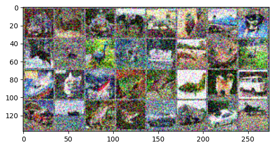

```
truck  deer  frog horse horse  bird plane   dog  deer  bird  bird  ship  ship  deer  frog  bird  ship   cat plane  frog  frog plane   dog   car truck  ship  frog  frog   car truck   car plane
5000
5000
0
Done calculating HOGs for training
(5000, 324)
0
1000
2000
3000
4000
Done calculating HOGs for testing
(5000, 324)
              precision    recall  f1-score   support

           0       0.55      0.62      0.58       488
           1       0.69      0.70      0.69       505
           2       0.47      0.47      0.47       512
           3       0.36      0.35      0.36       497
           4       0.48      0.48      0.48       507
           5       0.41      0.38      0.39       488
           6       0.58      0.63      0.61       491
           7       0.62      0.56      0.59       495
           8       0.61      0.64      0.62       504
           9       0.67      0.64      0.65       513

    accuracy                           0.55      5000
   macro avg       0.55      0.55      0.55      5000
weighted avg       0.55      0.55      0.55      5000
```

```python
# Your code goes here

import torch
import torchvision
import torchvision.transforms as transforms
transform = transforms.Compose(
    [transforms.ToTensor(),
     transforms.Normalize((0.5, 0.5, 0.5), (0.5, 0.5, 0.5))])

transformNoise = transforms.Compose(
    [transforms.ToTensor(),
     transforms.Normalize((0,0,0), (0.2, 0.2, 0.2))])

classes = ('plane', 'car', 'bird', 'cat',
           'deer', 'dog', 'frog', 'horse', 'ship', 'truck')

batch_size = 32

trainset = torchvision.datasets.CIFAR10(root='./data', train=True,
                                        download=True, transform=transform)
testset = torchvision.datasets.CIFAR10(root='./data', train=False,
                                       download=True, transform=transformNoise)



trainset.data = trainset.data[:5000]
trainset.targets = trainset.targets[:5000]
testset.data = testset.data[:5000]
testset.targets = testset.targets[:5000]

trainloader = torch.utils.data.DataLoader(trainset, batch_size=batch_size,
                                          shuffle=True, num_workers=4)
testloader = torch.utils.data.DataLoader(testset, batch_size=batch_size,
                                         shuffle=False, num_workers=4)

import matplotlib.pyplot as plt
import numpy as np

# functions to show an image


def imshow(img):
    img = img / 2 + 0.5     # unnormalize
#     print(img)
#     print(img.shape)
    img = img + (torch.randn(img.shape) * 0.2)
    npimg = img.numpy()
    plt.imshow(np.transpose(npimg, (1, 2, 0)))
    plt.show()


# get some random training images
dataiter = iter(trainloader)
images, labels = next(dataiter)


# show images
imshow(torchvision.utils.make_grid(images))
# print labels
print(' '.join('%5s' % classes[labels[j]] for j in range(batch_size)))


import matplotlib.pyplot as plt
import numpy as np

# Import datasets, classifiers and performance metrics
from sklearn import datasets, metrics, svm
from sklearn.naive_bayes import GaussianNB
from sklearn.metrics import classification_report


train_n_samples = len(trainset.data)
print(train_n_samples)
test_n_samples = len(testset.data)
print(test_n_samples)

Xtrain = trainset.data
Xtest  = testset.data
# Xtest = Xtest + (torch.randn(Xtest.shape) * 0.2)


from skimage.feature import hog
Xtrain_hog = []
for i in range(len(Xtrain)):
    fd  = hog(Xtrain[i] , orientations=9 , pixels_per_cell = (8,8),
                     cells_per_block = (2,2) , visualize = False, channel_axis=-1)
    Xtrain_hog.append(fd)
    if ((i % 10000) == 0):
        print(i)

Xtrain_hog = np.array(Xtrain_hog)
print('Done calculating HOGs for training')
print(Xtrain_hog.shape)

Xtest_hog = []
for i in range(len(Xtest)):
    fd = hog(Xtest[i], orientations=9 , pixels_per_cell = (8,8),
                     cells_per_block = (2,2) , visualize = False, channel_axis=-1)
    Xtest_hog.append(fd)
    if ((i % 1000) == 0):
        print(i)

Xtest_hog = np.array(Xtest_hog)
print('Done calculating HOGs for testing')
print(Xtest_hog.shape)
# for i in range(len(Xtest_hog)):
#     for j in range(len(Xtest_hog[i])):
#         Xtest_hog[i][j] = Xtest_hog[i][j] + (torch.randn(Xtest_hog.shape) * 0.2)

ytrain = trainset.targets
ytest  = testset.targets

from sklearn.decomposition import PCA
pca = PCA(0.8)
Xtrain_pca = pca.fit_transform(Xtrain_hog)
Xtest_pca  = pca.transform(Xtest_hog)
# print(Xtrain_pca.shape)
# print(Xtest_pca)

# %%time

from sklearn.metrics import confusion_matrix, ConfusionMatrixDisplay
# Create a classifier: a support vector classifier
clfsvm = svm.SVC(C=10, cache_size=10000)
clfsvm.fit(Xtrain_pca, ytrain)

ytest_predict  = clfsvm.predict(Xtest_pca)
print(classification_report(ytest, ytest_predict))

color = 'white'
cmSVM = confusion_matrix(ytest, ytest_predict)
disp = ConfusionMatrixDisplay(cmSVM, display_labels=['airplanes', 'cars', 'birds', 'cats', 'deer', 'dogs', 'frogs', 'horses', 'ships', 'trucks'])
disp.plot()
plt.xticks(rotation=45, ha='right')
plt.show()
print('')
```

[output not shown]

# QUESTION 9 (ADVANCED) - Synthetic generation of dataset

This question is a bit more open ended, will require some creativity and extra work. Your goal is to generate a synthetic dataset of shapes. Below is some code for generating some shapes with matplotlib. Your code should generate random shape using uniform random distributions along the following "dimensions": shape (square, circle, triangle, rhombus), color (red, green, blue, yellow, orange, black), size (continuous but should fit in the image), x-position (continuous but should fit in the image), y_position (continuous but should fit in the image). Once you create a plot you will need to figure out how to convert it to an image. All your images should be 64 by 64 which is bigger than the CIFAR-10 images. Generate a dataset that has 6000 instances of each shape, and 1000 instances of each color within each shape. Show some sample images by appropriately calling/modifying if needed the imshow() function from the deep learning notebook.

```python
import numpy as np
import matplotlib.pyplot as plt
from matplotlib.patches import Polygon, Circle, Rectangle

red, blue, yellow, green = '#ff0000', '#0000ff', '#ffff00', '#00ff00'
square = Rectangle((0.7, 0.1), 0.25, 0.25, facecolor=red)
circle = Circle((0.8, 0.8), 0.15, facecolor=blue)
triangle = Polygon(((0.05,0.1), (0.396,0.1), (0.223, 0.38)), fc=yellow)
rhombus = Polygon(((0.5,0.2), (0.7,0.525), (0.5,0.85), (0.3,0.525)),  fc=green)

fig = plt.figure()
ax = fig.add_subplot(111, facecolor='k', aspect='equal')
for shape in (square, circle, triangle, rhombus):
    ax.add_artist(shape)
ax.xaxis.set_visible(False)
ax.yaxis.set_visible(False)

plt.show()
```

# QUESTION 10 (ADVANCED) - Deep learning for the synthetic shapes

Using the deep learning notebook code as a template build a traditional machine learning classifier using Histogram-of-Oriented Gradients features followed by PCA and using a SVM as a classifier. Train classifiers for the following 3 problems: classify shape (irrespective of color), classify color (irrespective of shape), or classify both color and shape (you can train two SVMs one for each problem). Then repeat the same three configurations using a deep learning neural network. Report on the classification accuracy and confusion matrices for all 6 configurations (shape-SVM, color-SVM, shape+color SVM, shape-DNN, color-DNN, shape+color DNN).